# Practical Machine Learning - Course Project

Sheu Jeng-Long

11/30/2020

## I. Overview

Using devices such as Jawbone Up, Nike FuelBand, and Fitbit it is now possible to collect a large amount of data about personal activity relatively inexpensively. These type of devices are part of the quantified self movement – a group of enthusiasts who take measurements about themselves regularly to improve their health, to find patterns in their behavior, or because they are tech geeks. One thing that people regularly do is quantify how much of a particular activity they do, but they rarely quantify how well they do it. In this project, your goal will be to use data from accelerometers on the belt, forearm, arm, and dumbell of 6 participants. They were asked to perform barbell lifts correctly and incorrectly in 5 different ways. More information is available from the website here: http://groupware.les.inf.puc-rio.br/har (http://groupware.les.inf.puc-rio.br/har) (see the section on the Weight Lifting Exercise Dataset).

## II. Prepare and Data Loading

First at all, we need to load some packages which we’ll use.

```r
library(caret)
library(rpart)
library(rpart.plot)
```

The data consists of a Training data and a Test data (to be used to validate the selected model).The testing dataset is not changed and will only be used for the quiz.

```r
 UrlTrain <- "http://d396qusza40orc.cloudfront.net/predmachlearn/pml-training.csv"
 UrlTest  <- "http://d396qusza40orc.cloudfront.net/predmachlearn/pml-testing.csv"

 # download the datasets
 # testing dataset only used for QUIZ and named as validData
 training <- read.csv(url(UrlTrain))
 validData  <- read.csv(url(UrlTest))
```

```r
training <- read.csv("./pml-training.csv")
validData <- read.csv("./pml-testing.csv")
```

## III. Getting, Cleaning and Exploring the data

```r
dim(training)
```

```
## [1] 19622   160
```

```r
dim(validData)
```

```
## [1]  20 160
```

```r
str(training)
```

```
## 'data.frame':    19622 obs. of  160 variables:
##  $ X                       : int  1 2 3 4 5 6 7 8 9 10 ...
##  $ user_name               : chr  "carlitos" "carlitos" "carlitos" "carlitos" ...
##  $ raw_timestamp_part_1    : int  1323084231 1323084231 1323084231 1323084232 1323084232 1323084232 1323084232 1323084232 1323084232 1323084232 ...
##  $ raw_timestamp_part_2    : int  788290 808298 820366 120339 196328 304277 368296 440390 484323 484434 ...
##  $ cvtd_timestamp          : chr  "05/12/2011 11:23" "05/12/2011 11:23" "05/12/2011 11:23" "05/12/2011 11:23" ...
##  $ new_window              : chr  "no" "no" "no" "no" ...
##  $ num_window              : int  11 11 11 12 12 12 12 12 12 12 ...
##  $ roll_belt               : num  1.41 1.41 1.42 1.48 1.48 1.45 1.42 1.42 1.43 1.45 ...
##  $ pitch_belt              : num  8.07 8.07 8.07 8.05 8.07 8.06 8.09 8.13 8.16 8.17 ...
##  $ yaw_belt                : num  -94.4 -94.4 -94.4 -94.4 -94.4 -94.4 -94.4 -94.4 -94.4 -94.4 ...
##  $ total_accel_belt        : int  3 3 3 3 3 3 3 3 3 3 ...
##  $ kurtosis_roll_belt      : chr  "" "" "" "" ...
##  $ kurtosis_picth_belt     : chr  "" "" "" "" ...
##  $ kurtosis_yaw_belt       : chr  "" "" "" "" ...
```

[output cut: 86 more lines]

There are 19622 obs. and 160 variables in training dataset and it is quite large.After examining the structure of the data set, we found that the data and many of the values are “NA”.The existence of NA may affect the subsequent data analysis and model establishment, so we need to clean these data. Two methods are used here. First at all, use the nzv function in the caret package to process.

```r
nzv <- nzv(training)
training <- training[,-nzv]
dim(training)
```

```
## [1] 19622   100
```

After processing by the nzv() function, we can observe that the number of variables is reduced to 100. Next, we clean the variables in the data set whose values are NA.

```r
training<- training[, colSums(is.na(training)) == 0]
str(training)
```

```
## 'data.frame':    19622 obs. of  59 variables:
##  $ X                   : int  1 2 3 4 5 6 7 8 9 10 ...
##  $ user_name           : chr  "carlitos" "carlitos" "carlitos" "carlitos" ...
##  $ raw_timestamp_part_1: int  1323084231 1323084231 1323084231 1323084232 1323084232 1323084232 1323084232 1323084232 1323084232 1323084232 ...
##  $ raw_timestamp_part_2: int  788290 808298 820366 120339 196328 304277 368296 440390 484323 484434 ...
##  $ cvtd_timestamp      : chr  "05/12/2011 11:23" "05/12/2011 11:23" "05/12/2011 11:23" "05/12/2011 11:23" ...
##  $ num_window          : int  11 11 11 12 12 12 12 12 12 12 ...
##  $ roll_belt           : num  1.41 1.41 1.42 1.48 1.48 1.45 1.42 1.42 1.43 1.45 ...
##  $ pitch_belt          : num  8.07 8.07 8.07 8.05 8.07 8.06 8.09 8.13 8.16 8.17 ...
##  $ yaw_belt            : num  -94.4 -94.4 -94.4 -94.4 -94.4 -94.4 -94.4 -94.4 -94.4 -94.4 ...
##  $ total_accel_belt    : int  3 3 3 3 3 3 3 3 3 3 ...
##  $ gyros_belt_x        : num  0 0.02 0 0.02 0.02 0.02 0.02 0.02 0.02 0.03 ...
##  $ gyros_belt_y        : num  0 0 0 0 0.02 0 0 0 0 0 ...
##  $ gyros_belt_z        : num  -0.02 -0.02 -0.02 -0.03 -0.02 -0.02 -0.02 -0.02 -0.02 0 ...
##  $ accel_belt_x        : int  -21 -22 -20 -22 -21 -21 -22 -22 -20 -21 ...
```

[output cut: 45 more lines]

Looking at the data set, those variables which contain NA value are cleaned, leaving 59 variables in the entire data set.We split the data set into two parts, 70% of the data is used for model building and 30% of the data is used for accuracy verification.

```r
training <- training[,-c(1:5)]
training$classe <- as.factor(training$classe)

set.seed(123)
inTrain <- createDataPartition(training$classe, p=0.7)[[1]]
trainData = training[ inTrain,]
testData = training[-inTrain,]
```

## IV. Prediction Model Building

Three methods will be applied to model the regressions (in the Train dataset) and the best one (with higher accuracy when applied to the Test dataset) will be used for the quiz predictions.

We will test 3 different models :

- Classification Tree
- Random Forest
- Gradient Boosting Method(GBM)

In order to limit the effects of overfitting, and improve the efficicency of the models, we will use the *cross- validation technique.

In order to avoid the effects of overfitting, we will use the cross- validation technique and use 5 folds as argument.

## (a) train with Classification Tree

```r
trControl <- trainControl(method="cv", number=5)
# model build-up
mod_CT <- train(classe~., data=trainData, method="rpart", trControl=trControl)
mod_CT
```

```
## CART
##
## 13737 samples
##    53 predictor
##     5 classes: 'A', 'B', 'C', 'D', 'E'
##
## No pre-processing
## Resampling: Cross-Validated (5 fold)
## Summary of sample sizes: 10990, 10990, 10989, 10988, 10991
## Resampling results across tuning parameters:
##
##   cp          Accuracy   Kappa
##   0.04292544  0.4471986  0.2521757
##   0.04394263  0.4075045  0.1894835
##   0.11514597  0.3162864  0.0488818
##
## Accuracy was used to select the optimal model using the largest value.
## The final value used for the model was cp = 0.04292544.
```

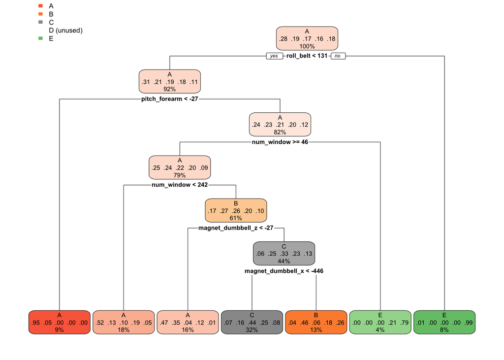

```r
# plot
rpart.plot(mod_CT$finalModel)
```

```r
pred_CT <- predict(mod_CT, newdata = testData)
confusionMatrix(pred_CT, testData$classe)$table
```

```
##           Reference
## Prediction    A    B    C    D    E
##          A 1496  474  166  317   59
##          B   38  390   50  137  190
##          C  138  275  810  471  178
##          D    0    0    0    0    0
##          E    2    0    0   39  655
```

```r
confusionMatrix(pred_CT, testData$classe)$overall["Accuracy"]
```

```
##  Accuracy
## 0.5694138
```

## (b) train with Random Forest

```r
# model build-up
mod_RF <- train(classe~., data=trainData, method="rf", trControl=trControl, verbose=FALSE)
mod_RF
```

```
## Random Forest
##
## 13737 samples
##    53 predictor
##     5 classes: 'A', 'B', 'C', 'D', 'E'
##
## No pre-processing
## Resampling: Cross-Validated (5 fold)
## Summary of sample sizes: 10988, 10990, 10991, 10990, 10989
## Resampling results across tuning parameters:
##
##   mtry  Accuracy   Kappa
##    2    0.9931574  0.9913441
##   27    0.9959965  0.9949357
##   53    0.9939583  0.9923576
##
## Accuracy was used to select the optimal model using the largest value.
## The final value used for the model was mtry = 27.
```

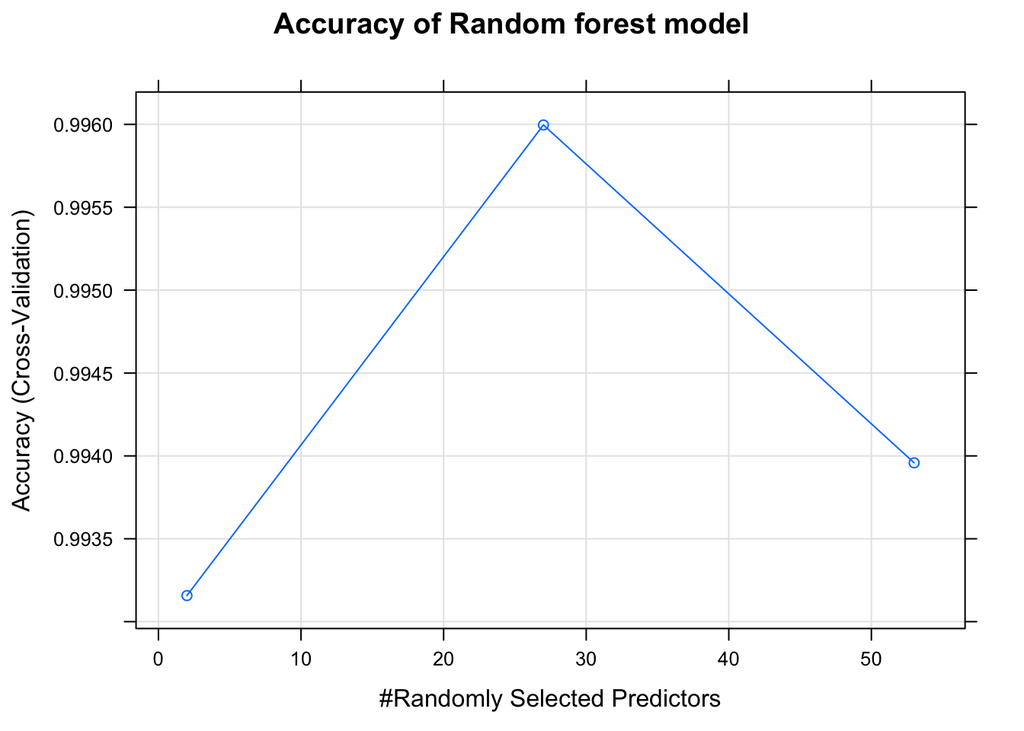

```r
# plot
plot(mod_RF, main="Accuracy of Random forest model" )
```

```r
pred_RF <- predict(mod_RF, newdata = testData)
confusionMatrix(pred_RF, testData$classe)$table
```

```
##           Reference
## Prediction    A    B    C    D    E
##          A 1674    1    0    0    0
##          B    0 1135    1    0    0
##          C    0    3 1025    1    1
##          D    0    0    0  963    4
##          E    0    0    0    0 1077
```

```r
confusionMatrix(pred_RF, testData$classe)$overall["Accuracy"]
```

```
##  Accuracy
## 0.9981308
```

The accuracy rate of the random forest method is as high as 99.8%, and the prediction utility is obviously better than classification tree method.Next, let’s try the GBM method and observe how accurately of the GBM method is?

## (c) train with Gradient Boosting Method

```r
mod_GBM <- train(classe~., data=trainData, method="gbm", trControl=trControl, verbose=FALSE)
mod_GBM
```

```
## Stochastic Gradient Boosting
##
## 13737 samples
##    53 predictor
##     5 classes: 'A', 'B', 'C', 'D', 'E'
##
## No pre-processing
## Resampling: Cross-Validated (5 fold)
## Summary of sample sizes: 10991, 10989, 10989, 10990, 10989
## Resampling results across tuning parameters:
##
##   interaction.depth  n.trees  Accuracy   Kappa
##   1                   50      0.7640681  0.7008193
##   1                  100      0.8327876  0.7883648
##   1                  150      0.8687490  0.8339161
##   2                   50      0.8793040  0.8471833
##   2                  100      0.9392879  0.9231800
##   2                  150      0.9616369  0.9514610
##   3                   50      0.9287329  0.9097780
##   3                  100      0.9712455  0.9636197
##   3                  150      0.9847133  0.9806637
##
## Tuning parameter 'shrinkage' was held constant at a value of 0.1
##
## Tuning parameter 'n.minobsinnode' was held constant at a value of 10
## Accuracy was used to select the optimal model using the largest value.
## The final values used for the model were n.trees = 150, interaction.depth =
##  3, shrinkage = 0.1 and n.minobsinnode = 10.
```

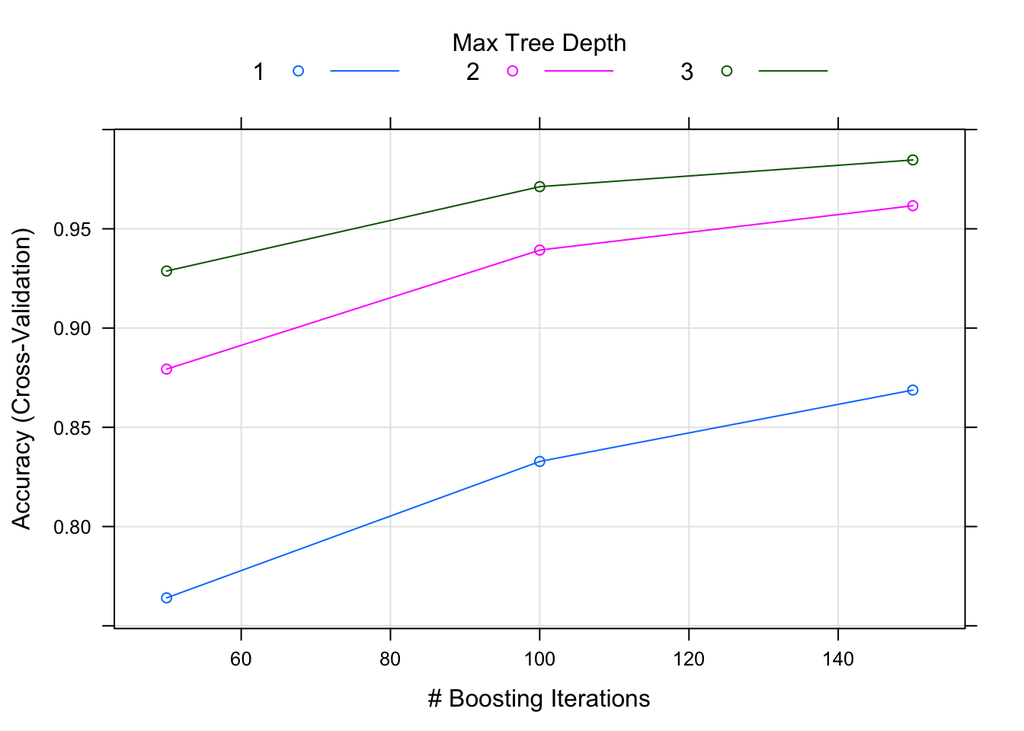

```r
plot(mod_GBM)
```

```r
pred_GBM <- predict(mod_GBM, newdata = testData)
confusionMatrix(pred_GBM, testData$classe)$table
```

```
##           Reference
## Prediction    A    B    C    D    E
##          A 1669    8    0    1    2
##          B    3 1116    9    3    1
##          C    0   12 1013    9    7
##          D    0    3    4  950   14
##          E    2    0    0    1 1058
```

```r
confusionMatrix(pred_GBM, testData$classe)$overall["Accuracy"]
```

```
## Accuracy
## 0.986576
```

## (d) conclusion

After using the three methods to build the model, we compare the accuracy of the three models, and the results are as follows:

```
##                 Model Accuracy
## 1 Classification Tree   0.5694
## 2       Random Forest   0.9981
## 3                 GBM   0.9866
```

We found that the accuracy of the RF method is the best. Here we choose the RF method as the final prediction algorithm and apply it to validData for prediction.

## V. Applying the Selected Model to the validData

```r
pred_valid <- predict(mod_RF, newdata = validData)
pred_valid
```

```
##  [1] B A B A A E D B A A B C B A E E A B B B
## Levels: A B C D E
```